# *Vanessa cardui* DE

# Differntial expression in *Vanessa cardui* adults

Experimental set up was prepared with adult females in two food availability conditions: ad libitum and no resources, to analyze the influence that environmental conditions may have on investment in migration or reproduction in imagines

## Abdomen tissue

In this section we analyse differential expression in the abdomen tissue

**Preparing data** We upload count data from the DESeq2 object crated within the nf-core rnasq pipeline. Pipeline was run for the entire experimental dataset therefore needs to be split into different sets/tissues:

Pipeline was run for the entire experimental dataset therefore needs to be split into different sets/tissues:

```r
colDataLRab<-colDataLR[colDataLR$tissue == "A", ] #selecting abdomen samples only
#selecting samples with abdomen tissue based on ID
countLRab<-countLR[,c(1,2,3,4,5,10,11,12,13,14)]
names(colDataLRab)[names(colDataLRab)=="Group3"]<-"tissue"
names(colDataLRab)[names(colDataLRab)=="Group1"]<-"condition"

head(countLR)
```

```
                AL_ADF_A_11 AL_ADF_A_19 AL_ADF_A_3 AL_ADF_A_7 AL_ADF_A_9 AL_ADF_H_11 AL_ADF_H_3 AL_ADF_H_7
Vcard_DToL00001           0           0          0          0          0           0          0          0
Vcard_DToL00002           0           0          0          0          0           0          0          0
Vcard_DToL00003           0           0          0          0          0           0          0          0
Vcard_DToL00004           0           0          0          0          0           0          0          0
Vcard_DToL00005           0           0          0          0          0           0          0          0
Vcard_DToL00006           0           0          0          0          0           0          0          0
                AL_ADF_H_9 LI_ADF_A_10 LI_ADF_A_12 LI_ADF_A_14 LI_ADF_A_16 LI_ADF_A_8 LI_ADF_H_10 LI_ADF_H_12
Vcard_DToL00001          0           0           0           0           0          0           0           0
Vcard_DToL00002          0           0           0           0           0          0           0           0
Vcard_DToL00003          0           0           0           0           0          0           0           0
Vcard_DToL00004          0           0           0           0           0          0           0           0
Vcard_DToL00005          0           0           0           0           0          0           0           0
Vcard_DToL00006          0           0           0           0           0          0           0           0
                LI_ADF_H_14 LI_ADF_H_16 LI_ADF_H_8
Vcard_DToL00001           0           0          0
Vcard_DToL00002           0           0          0
Vcard_DToL00003           0           0          0
Vcard_DToL00004           0           0          0
Vcard_DToL00005           0           0          0
Vcard_DToL00006           0           2          0
```

```r
head(colDataLR)
```

```
DataFrame with 6 rows and 5 columns
                 sample   condition      tissue      Group4 sizeFactor
            <character> <character> <character> <character>  <numeric>
AL_ADF_A_11 AL_ADF_A_11          AL           A          11   1.117485
AL_ADF_A_19 AL_ADF_A_19          AL           A          19   1.035097
AL_ADF_A_3   AL_ADF_A_3          AL           A           3   1.056977
AL_ADF_A_7   AL_ADF_A_7          AL           A           7   0.883751
AL_ADF_A_9   AL_ADF_A_9          AL           A           9   1.579290
AL_ADF_H_11 AL_ADF_H_11          AL           H          11   0.826602
```

Constructing DESeq2 object, at this point counts are transformed according to the DESeq specific algorithm. Current hypothsis includes split into treatment groups *only* (~condition), filtering out genes with less then 10 total counts

```r
ddsLRab <- DESeqDataSetFromMatrix(countData=countLRab, colData =colDataLRab, design = ~condition)
```

```
some variables in design formula are characters, converting to factors
```

```r
#Basic filtering
keep <- rowSums(counts(ddsLRab)) >= 10
ddsLRab <- ddsLRab[keep,]
head(ddsLRab)
```

```
class: DESeqDataSet
dim: 6 10
metadata(1): version
assays(1): counts
rownames(6): Vcard_DToL00007 Vcard_DToL00010 ... Vcard_DToL00013 Vcard_DToL00014
rowData names(0):
colnames(10): AL_ADF_A_11 AL_ADF_A_19 ... LI_ADF_A_16 LI_ADF_A_8
colData names(5): sample condition tissue Group4 sizeFactor
```

**DESeq analysis** Main valuation, calculation of p-values

```r
#ddsLRab <- DESeq(ddsLRab) #running the main function
resLRab <- results(ddsLRab)
resLRab <- resLRab[order(resLRab$padj),]
head(resLRab)
```

```
log2 fold change (MLE): condition LI vs AL
Wald test p-value: condition LI vs AL
DataFrame with 6 rows and 6 columns
                 baseMean log2FoldChange     lfcSE      stat      pvalue        padj
                <numeric>      <numeric> <numeric> <numeric>   <numeric>   <numeric>
Vcard_DToL13592   541.427       -1.89555  0.313908  -6.03855 1.55504e-09 1.56422e-05
Vcard_DToL04829    52.077       -2.30664  0.401831  -5.74031 9.45037e-09 4.75306e-05
Vcard_DToL13539   274.921        1.23667  0.269397   4.59051 4.42161e-06 1.48257e-02
Vcard_DToL02600   478.949       -2.46656  0.567757  -4.34440 1.39658e-05 3.27025e-02
Vcard_DToL10357   334.966       -1.37088  0.323629  -4.23596 2.27575e-05 3.27025e-02
Vcard_DToL13220   160.525        4.34707  1.023610   4.24681 2.16838e-05 3.27025e-02
```

```r
summary(resLRab)
```

```
out of 11237 with nonzero total read count
adjusted p-value < 0.1
LFC > 0 (up)       : 10, 0.089%
LFC < 0 (down)     : 12, 0.11%
outliers [1]       : 112, 1%
low counts [2]     : 1066, 9.5%
(mean count < 5)
[1] see 'cooksCutoff' argument of ?results
[2] see 'independentFiltering' argument of ?results
```

Setting up p-value to 0.05

```r
res05 <- results(ddsLRab, alpha=0.05)
summary(res05)
```

```
out of 11237 with nonzero total read count
adjusted p-value < 0.05
LFC > 0 (up)       : 2, 0.018%
LFC < 0 (down)     : 5, 0.044%
outliers [1]       : 112, 1%
low counts [2]     : 0, 0%
(mean count < 1)
[1] see 'cooksCutoff' argument of ?results
[2] see 'independentFiltering' argument of ?results
```

Log fold change shrinkage is recommended for visualization and ranking, her we follow main DESEq2 vignette exactly

"Shrinkage of effect size (LFC estimates) is useful for visualization and ranking of genes. To shrink the LFC, we pass the dds object to the function lfcShrink. Below we specify to use the apeglm method for effect size shrinkage (Zhu, Ibrahim, and Love 2018), which improves on the previous estimator.

We provide the dds object and the name or number of the coefficient we want to shrink, where the number refers to the order of the coefficient as it appears in resultsNames(dds)."

```r
head(resultsNames(ddsLRab))
```

```
[1] "Intercept"          "condition_LI_vs_AL"
```

```r
resLFC <- lfcShrink(ddsLRab, coef="condition_LI_vs_AL", type="apeglm")
```

[output not shown]

Visual exploration of the results

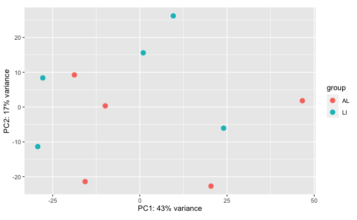

```r
vsdata <- vst(ddsLRab, blind=FALSE)
plotPCA(vsdata, intgroup=c("condition"))
```

We use function plotMA, that shows the log2 fold changes attributable to a given variable over the mean of normalized counts for all the samples in the DESeqDataSet. Points are colored blue if the adjusted p-value is less than 0.1.

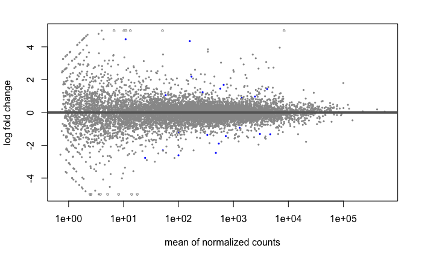

```r
plotMA(resLRab, ylim=c(-5,5))
```

Checking significant gene candidates:

```r
res <- resLRab[order(resLRab$padj),]
head(res, 10)
```

```
log2 fold change (MLE): condition LI vs AL
Wald test p-value: condition LI vs AL
DataFrame with 10 rows and 6 columns
                 baseMean log2FoldChange     lfcSE      stat      pvalue        padj
                <numeric>      <numeric> <numeric> <numeric>   <numeric>   <numeric>
Vcard_DToL13592  541.4268       -1.89555  0.313908  -6.03855 1.55504e-09 1.56422e-05
Vcard_DToL04829   52.0770       -2.30664  0.401831  -5.74031 9.45037e-09 4.75306e-05
Vcard_DToL13539  274.9208        1.23667  0.269397   4.59051 4.42161e-06 1.48257e-02
Vcard_DToL02600  478.9490       -2.46656  0.567757  -4.34440 1.39658e-05 3.27025e-02
Vcard_DToL10357  334.9660       -1.37088  0.323629  -4.23596 2.27575e-05 3.27025e-02
Vcard_DToL13220  160.5249        4.34707  1.023610   4.24681 2.16838e-05 3.27025e-02
Vcard_DToL16018   24.6975       -2.76963  0.650293  -4.25905 2.05300e-05 3.27025e-02
Vcard_DToL01847  664.3799        1.67992  0.429905   3.90765 9.31980e-05 8.13203e-02
Vcard_DToL04245 4685.0017       -1.32700  0.334322  -3.96925 7.21005e-05 8.13203e-02
Vcard_DToL05076  100.0051       -2.60856  0.677126  -3.85240 1.16968e-04 8.13203e-02
```

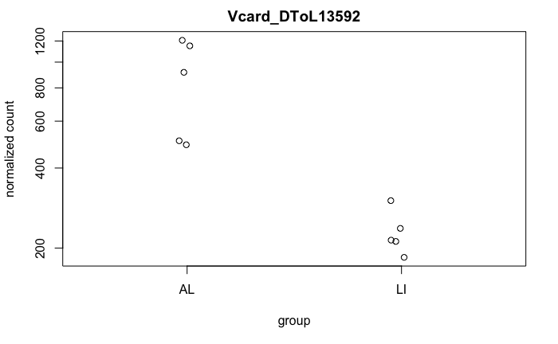

```r
#Plotting these genes
plotCounts(ddsLRab, gene="Vcard_DToL13592", intgroup="condition")
```

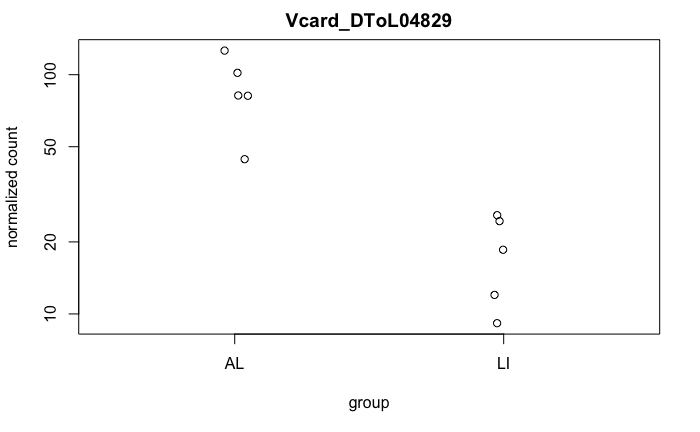

```r
plotCounts(ddsLRab, gene="Vcard_DToL04829", intgroup="condition")
```

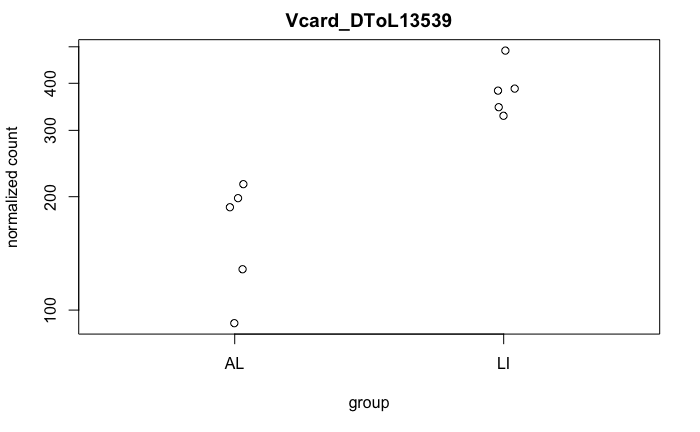

```r
plotCounts(ddsLRab, gene="Vcard_DToL13539", intgroup="condition")
```

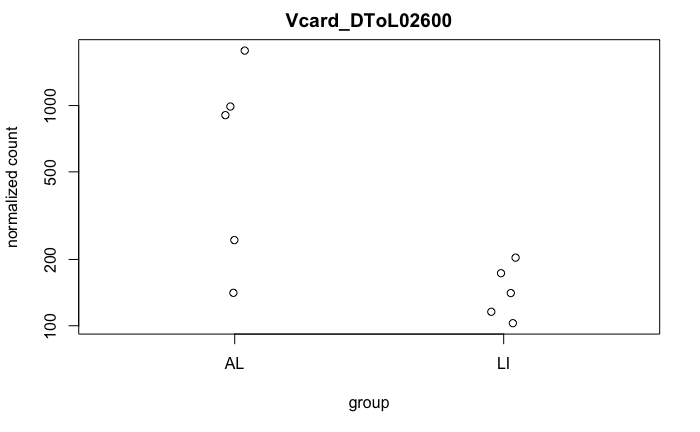

```r
plotCounts(ddsLRab, gene="Vcard_DToL02600", intgroup="condition")
```

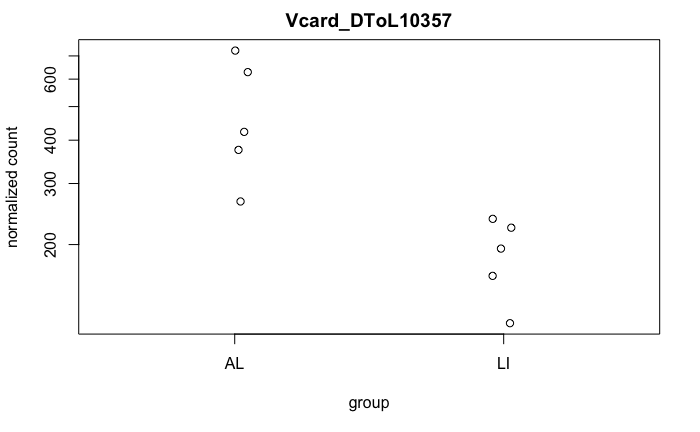

```r
plotCounts(ddsLRab, gene="Vcard_DToL10357", intgroup="condition")
```

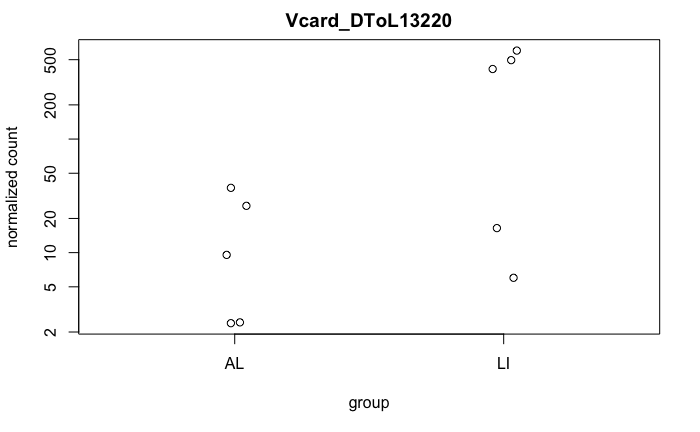

```r
plotCounts(ddsLRab, gene="Vcard_DToL13220", intgroup="condition")
```

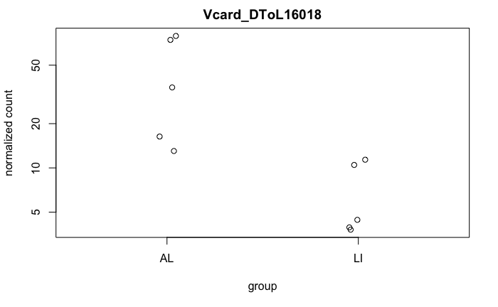

```r
plotCounts(ddsLRab, gene="Vcard_DToL16018", intgroup="condition")
```

Checking functions of the differentialy expressed genes

```bash
#ls
grep "Vcard_DToL13592" vcard.func.annot.csv | awk -F "," '{print $1,$15,$16}'
grep "Vcard_DToL04829" vcard.func.annot.csv | awk -F "," '{print $1,$14,$15}'
grep "Vcard_DToL13539" vcard.func.annot.csv | awk -F "," '{print $1,$15,$16}'
grep "Vcard_DToL02600" vcard.func.annot.csv | awk -F "," '{print $1,$15,$16}'
grep "Vcard_DToL10357" vcard.func.annot.csv | awk -F "," '{print $1,$15,$16}'
grep "Vcard_DToL13220" vcard.func.annot.csv | awk -F "," '{print $1,$15,$16}'
grep "Vcard_DToL16018" vcard.func.annot.csv | awk -F "," '{print $1,$15,$16}'
```

```
Vcard_DToL13592-RA - -
Vcard_DToL04829-RA "Zinc-binding domain present in Lin-11  Isl-1
Vcard_DToL13539-RA "Insect pheromone-binding family  A10/OS-D"
Vcard_DToL02600-RA SCP / Tpx-1 / Ag5 / PR-1 / Sc7 family of extracellular domains. glipr2
Vcard_DToL10357-RA Leucine Rich repeat chp
Vcard_DToL13220-RA Insect cuticle protein -
Vcard_DToL16018-RA Protein of unknown function (DUF1676) Osi9
```

```bash
grep "Vcard_DToL13592" vcard.func.annot.csv
grep "Vcard_DToL04829" vcard.func.annot.csv
grep "Vcard_DToL13539" vcard.func.annot.csv
grep "Vcard_DToL02600" vcard.func.annot.csv
grep "Vcard_DToL10357" vcard.func.annot.csv
grep "Vcard_DToL13220" vcard.func.annot.csv
grep "Vcard_DToL16018" vcard.func.annot.csv
```

```
Vcard_DToL13592-RA,34740.HMEL017653-PA,2.5e-209,734.9,"2EXVD@1|root,2SZFT@2759|Eukaryota,39N11@33154|Opisthokonta,3CPK6@33208|Metazoa,3E5R8@33213|Bilateria,42AT4@6656|Arthropoda,3T06F@50557|Insecta,442QT@7088|Lepidoptera",33208|Metazoa,-,-,-,-,-,-,-,-,-,-,-,-,-,-,-
Vcard_DToL04829-RA,13037.EHJ68824,8.7e-32,142.5,"KOG1704@1|root,KOG1704@2759|Eukaryota,39ZNF@33154|Opisthokonta,3BP8A@33208|Metazoa,3D53G@33213|Bilateria,41WV2@6656|Arthropoda,3SYZB@50557|Insecta",33208|Metazoa,TZ,"Zinc-binding domain present in Lin-11, Isl-1, Mec-3.",-,-,-,-,-,-,-,-,-,-,-,-,LIM
Vcard_DToL13539-RA,34740.HMEL010992-PA,2.4e-41,174.9,"2CRZI@1|root,2TM2F@2759|Eukaryota,39I99@33154|Opisthokonta,3CN28@33208|Metazoa,3E3QK@33213|Bilateria,42CPD@6656|Arthropoda,3SY6C@50557|Insecta,44ABT@7088|Lepidoptera",33208|Metazoa,S,"Insect pheromone-binding family, A10/OS-D",-,-,-,-,-,-,-,-,-,-…
Vcard_DToL02600-RA,34740.HMEL004173-PA,1.1e-168,599.7,"COG2340@1|root,KOG3017@2759|Eukaryota,3A626@33154|Opisthokonta,3BGGC@33208|Metazoa,3CWAY@33213|Bilateria,41XZM@6656|Arthropoda,3SKAW@50557|Insecta,446MH@7088|Lepidoptera",33208|Metazoa,S,SCP / Tpx-1 / Ag5 / PR-1 / Sc7 family of extracellular dom…
Vcard_DToL10357-RA,7091.BGIBMGA006308-TA,1.8e-128,466.5,"COG4886@1|root,KOG0619@2759|Eukaryota,38GPY@33154|Opisthokonta,3BFMX@33208|Metazoa,3CS8Y@33213|Bilateria,41YFQ@6656|Arthropoda,3SJHG@50557|Insecta,449FV@7088|Lepidoptera",33208|Metazoa,S,Leucine Rich repeat,chp,"GO:0001654,GO:0001745,GO:000175…
Vcard_DToL13220-RA,34740.HMEL005078-PA,3e-74,284.6,"2EZC0@1|root,2T0PM@2759|Eukaryota,3AS0F@33154|Opisthokonta,3C3JC@33208|Metazoa,3DJFA@33213|Bilateria,423HU@6656|Arthropoda,3T0RB@50557|Insecta,446DP@7088|Lepidoptera",33208|Metazoa,S,Insect cuticle protein,-,-,-,-,-,-,-,-,-,-,-,-,Chitin_bind_4
Vcard_DToL16018-RA,13037.EHJ76665,3.7e-99,367.9,"2AK5C@1|root,2RZ8R@2759|Eukaryota,3A27N@33154|Opisthokonta,3BR2Q@33208|Metazoa,3D7SY@33213|Bilateria,41ZJ7@6656|Arthropoda,3SKJ6@50557|Insecta,448EI@7088|Lepidoptera",33208|Metazoa,S,Protein of unknown function (DUF1676),Osi9,"GO:0005575,GO:0005623,GO…
```

```r
tab <- matrix(c("N/A", "N/A", "Isl-1", "Insulin gene enhancer protein, gene encodes a transcription factor containing two N-terminal LIM domains and one C-terminal homeodomain","A10/OS-D","Insect pheromone-binding family","glipr2",1,1,1,1,1,1,1), ncol=2, byrow=TRUE)
colnames(tab) <- c('GeneName','Function')
rownames(tab) <- c('Vcard_DToL13592',"Vcard_DToL04829","Vcard_DToL13539","Vcard_DToL02600","Vcard_DToL10357","Vcard_DToL13220","Vcard_DToL16018" )
tab <- as.table(tab)

tab
```

[output not shown]